# Feature Engineering

In this tutorial, we will learn about resampling and feature engineering with the `rsample` and `recipes` packages from `tidymodels`.

The first step in fitting a machine learning algorithm involves splitting our data into training and test sets as well as processing our data into a numeric feature matrix.

# Data Resampling

In machine learning, splitting data into training and test sets is known as resampling, or more generally as cross validation. This is an important step in the model fitting process because it allows us to estimate how our trained machine learning algorithms with perform on new data.

The ultimate goal for any machine learning algorithm is to provide accurate predictions on new, previously unseen data.

Resampling is achieved with the `rsample` package from `tidymodels`. To demonstrate how this done, let’s import the `tidymodels` package and the `employee_data`.

The `tidymodels` package loads the core machine learning packages that we will be using this semester, including `rsample`, `recipes`, `parsnip`, `yardstick`, `dials`, `tune`, and `workflows`. Each one of these packages serves a specific role in the modeling process. This tutorial will focus on resampling with `rsample` and feature engineering with `recipes`.

We also load the `tidyverse` package for reading in our data and data manipulation.

```r
library(tidymodels)
library(tidyverse)
library(vip)
employee_data <- read_rds('employee_data.rds')
```

The code below creates a subset of the `employee_data` with select columns and a new `employee_id` variable. This is so that we can easily demonstrate the use of the `recipes` package in the next section.

```r
employee_df <- employee_data %>%
               #select(left_company, job_level, salary, weekly_hours, miles_from_home) %>%
               mutate(employee_id = row_number()) %>% # generate id for each employee
               relocate(employee_id, .before = left_company) # move id before left_company

# View results
employee_df
```

| employee_id | left_company | department | job_level | salary | weekly_hours | business_travel | yrs_at_company | yrs_since_promotion | previous_companies | job_satisfaction | performance_rating | marital_status | miles_from_home |
| --- | --- | --- | --- | --- | --- | --- | --- | --- | --- | --- | --- | --- | --- |
| 1 | Yes | Sales | Director | 118680.74 | 56 | Rarely | 6 | 0 | 5 | Very High | Meets Expectations | Single | 1 |
| 2 | No | Sales | Senior Manager | 85576.44 | 42 | Frequently | 10 | 1 | 5 | Medium | Exceeds Expectations | Married | 8 |
| 3 | Yes | Product Development | Associate | 46235.79 | 56 | Rarely | 0 | 0 | 6 | High | Minimally Effective | Single | 2 |
| 4 | No | IT and Analytics | Director | 117226.84 | 50 | Frequently | 8 | 3 | 1 | High | Exceptional | Married | 3 |
| 5 | No | Sales | Associate | 36634.73 | 46 | Rarely | 2 | 2 | 2 | Medium | Exceeds Expectations | Married | 2 |
| 6 | No | Marketing | Senior Manager | 83519.59 | 48 | Frequently | 7 | 3 | 1 | Very High | Meets Expectations | Single | 2 |
| 7 | No | Marketing | Senior Manager | 88555.65 | 44 | Rarely | 1 | 0 | 3 | Low | Meets Expectations | Married | 3 |
| 8 | No | Sales | Director | 122280.88 | 47 | Rarely | 1 | 0 | 3 | High | Exceptional | Divorced | 24 |
| 9 | No | Finance and Operations | Senior Manager | 94642.18 | 50 | Frequently | 9 | 1 | 3 | High | Meets Expectations | Single | 23 |
| 10 | No | Product Development | Director | 124537.85 | 51 | Rarely | 7 | 7 | 3 | High | Exceeds Expectations | Married | 27 |

[output cut: 1460 more lines]

## Data Splitting

The `initial_split()` function from the `rsample`package is used for generating a data split object with instructions for randomly assigning rows from a data frame to a training set and test set. Once the object is created, we can use the `training()` and `testing()` functions to obtain the two data frames from the object.

When splitting data, it is important to use the `set.seed()` function before calling `initial_split()`. The `set.seed()` function takes any integer as an argument and sets the random number generator in `R` to a specific starting point. When this is done, the data split will be random the first time our code is executed. Every execution afterwards, will produce the same data split. This guarantees reproducibility.

The `initial_split()` function takes three important arguments, our data, the proportion of rows to add to our training set (`prop`), and the variable to use for stratification, `strata`.

## Creating a Data Split Object

First, let’s create a data split object named `employee_split`

```r
# Set the random seed
set.seed(3198)

employee_split <- initial_split(employee_df, prop = 0.75, strata = salary)
```

```r
employee_split
```

```
## <Training/Testing/Total>
## <1102/368/1470>
```

## Extracting Training and Test Sets

To create training and test data frames from our `employee_split` object, we must pass `employee_split` to the `training()` and `testing()` functions.

The code below shows how to do this with the `%>%` operator. I have named the resulting data frames `employee_training` and `employee_test`.

```r
# Generate a training data frame
employee_training <- employee_split %>% training()

# View results
employee_training
```

| employee_id | left_company | department | job_level | salary | weekly_hours | business_travel | yrs_at_company | yrs_since_promotion | previous_companies | job_satisfaction | performance_rating | marital_status | miles_from_home |
| --- | --- | --- | --- | --- | --- | --- | --- | --- | --- | --- | --- | --- | --- |
| 3 | Yes | Product Development | Associate | 46235.79 | 56 | Rarely | 0 | 0 | 6 | High | Minimally Effective | Single | 2 |
| 5 | No | Sales | Associate | 36634.73 | 46 | Rarely | 2 | 2 | 2 | Medium | Exceeds Expectations | Married | 2 |
| 12 | No | Research | Manager | 69565.51 | 48 | Rarely | 9 | 0 | 3 | High | Exceptional | Single | 15 |
| 15 | Yes | Marketing | Manager | 63876.58 | 57 | Rarely | 4 | 0 | 2 | High | Minimally Effective | Single | 24 |
| 17 | No | Research | Associate | 41883.73 | 44 | Rarely | 6 | 0 | 3 | Medium | Meets Expectations | Divorced | 5 |
| 20 | No | IT and Analytics | Manager | 67105.33 | 48 | Rarely | 3 | 1 | 3 | Very High | Meets Expectations | Single | 2 |
| 24 | No | Marketing | Manager | 69888.14 | 47 | Rarely | 0 | 0 | 2 | Very High | Meets Expectations | Single | 15 |
| 26 | No | Marketing | Manager | 62391.23 | 51 | Rarely | 14 | 4 | 1 | High | Meets Expectations | Divorced | 5 |
| 30 | No | Marketing | Associate | 37230.25 | 51 | Rarely | 2 | 2 | 2 | Low | Exceeds Expectations | Single | 2 |
| 37 | Yes | Sales | Associate | 38538.66 | 57 | Rarely | 3 | 0 | 6 | High | Minimally Effective | Married | 3 |

[output cut: 1092 more lines]

```r
# Generate a training data frame
employee_test <- employee_split %>% testing()

# View results
employee_test
```

| employee_id | left_company | department | job_level | salary | weekly_hours | business_travel | yrs_at_company | yrs_since_promotion | previous_companies | job_satisfaction | performance_rating | marital_status | miles_from_home |
| --- | --- | --- | --- | --- | --- | --- | --- | --- | --- | --- | --- | --- | --- |
| 7 | No | Marketing | Senior Manager | 88555.65 | 44 | Rarely | 1 | 0 | 3 | Low | Meets Expectations | Married | 3 |
| 11 | No | Sales | Director | 122820.53 | 46 | Rarely | 5 | 0 | 1 | Medium | Exceeds Expectations | Married | 16 |
| 13 | No | Sales | Associate | 41985.50 | 48 | Rarely | 5 | 4 | 2 | High | Meets Expectations | Divorced | 26 |
| 14 | No | Sales | Director | 117368.60 | 48 | Rarely | 2 | 1 | 2 | Very High | Meets Expectations | Divorced | 19 |
| 22 | Yes | Finance and Operations | Manager | 56461.39 | 58 | Rarely | 5 | 0 | 3 | Low | Minimally Effective | Single | 9 |
| 25 | Yes | Marketing | Director | 108649.20 | 54 | Rarely | 4 | 1 | 3 | Low | Meets Expectations | Single | 6 |
| 27 | Yes | Research | Director | 119443.17 | 62 | Frequently | 10 | 6 | 6 | Low | Meets Expectations | Single | 16 |
| 31 | No | Marketing | Manager | 73141.97 | 49 | Rarely | 1 | 0 | 1 | Very High | Meets Expectations | Single | 2 |
| 46 | Yes | Research | Manager | 58286.27 | 62 | Rarely | 22 | 15 | 4 | High | Not Effective | Married | 12 |
| 47 | No | IT and Analytics | Manager | 55826.66 | 51 | None | 9 | 8 | 1 | High | Meets Expectations | Single | 23 |

[output cut: 358 more lines]

# Feature Engineering

Feature engineering includes all transformations that take a training data set and turn it into a **numeric feature matrix**.

Typical steps include:

- Scaling and centering numeric predictors
- Removing skewness from numeric variables
- One-hot and dummy variable encoding for categorical variables
- Removing correlated predictors and zero variance variables
- Imputing missing data

Feature engineering steps should be trained on the **training data**. This includes things such as learning the means and standard deviations to apply in standardizing numeric predictors.

Once these are calculated in the training data, the same transforms are performed on the test data. This way, the test data is completely removed from the training process and can serve as an independent assessment for model performance.

## Specify a Recipe

The first step in build a feature engineering pipeline with the `recipes` package is to specify a blueprint for processing data and assigning roles to each column of the training data.

This is done with the `recipe()` function. This function takes two important arguments:

- a model formula
- a data frame for training the recipe

Model formulas in `R` have the following form:

`response ~ predictor_1 + predictor_2 + ...`

The response variable is on the left side of the `~` followed by all predictors separated by a `+` on the righthand side.

Typically, model formulas are written using shorthand notation. When we type `left_company ~ .`, we are telling `R` that `left_company` is the response variable and all other variables should be used as predictors. This saves us from have to type out each predictor variable separated by a `+`.

Let’s specify our feature engineering recipe using the `employee_training` data and the `recipe()` function. We will name our `recipe` object `employee_recipe`

```r
employee_recipe <- recipe(salary ~ .,
                          data = employee_training)
```

To explore the variable roles in our recipe, we can pass our recipe object to the `summary()` function. This will return a data frame with 4 columns. The important columns are `variable`, `type`, and `role`.

The `variable` column lists all the columns in the input data, `employee_training` in this case.

The `type` column lets us know what data type each variable has in our training data.

```r
summary(employee_recipe)
```

| variable | type | role | source |
| --- | --- | --- | --- |
| employee_id |  | predictor | original |
| left_company |  | predictor | original |
| department |  | predictor | original |
| job_level |  | predictor | original |
| weekly_hours |  | predictor | original |
| business_travel |  | predictor | original |
| yrs_at_company |  | predictor | original |
| yrs_since_promotion |  | predictor | original |
| previous_companies |  | predictor | original |
| job_satisfaction |  | predictor | original |

[output cut: 4 more lines]

## Updating Variable Roles

Unfortunately, the `employee_id` variable is assigned as a predictor when in fact it serves as an ID column. ID columns are useful for studying why certain employees may have gotten a specific prediction, but they should never be used as predictor variables.

We can update the role of any variable within a recipe by using the `update_role()` function. This function takes a recipe object as input along with the variables to update and their new roles.

In the code below, we will update the role of `employee_id` to “id variable”. This will exclude the variable from feature engineering and modeling steps.

```r
employee_recipe <- employee_recipe %>%
                   update_role(employee_id, new_role = "id variable")

# View updated roles
summary(employee_recipe)
```

| variable | type | role | source |
| --- | --- | --- | --- |
| employee_id |  | id variable | original |
| left_company |  | predictor | original |
| department |  | predictor | original |
| job_level |  | predictor | original |
| weekly_hours |  | predictor | original |
| business_travel |  | predictor | original |
| yrs_at_company |  | predictor | original |
| yrs_since_promotion |  | predictor | original |
| previous_companies |  | predictor | original |
| job_satisfaction |  | predictor | original |

[output cut: 4 more lines]

Now we are ready to process our data with feature engineering steps.

## Processing Numeric Variables

Once we have specified a recipe with a formula, data, and correct variables roles, we can add data transformation steps with a series of `step()` functions. Each `step()` function in the `recipes` package provides functionality for different kinds of common transformations.

### Center and Scale

Let’s begin with the simple task of centering and scaling numeric predictor variables. We have been doing this when we subtracted the mean and divided by the standard deviation in our previous tutorials.

The associated `step()` functions for this task are `step_center()` and `step_scale()`. The `step_center()` function subtracts the column mean from a variable and `step_scale()` divides by the standard deviation.

Each successive `step()` function adds a preprocessing step to our recipe object in the order that they are provided.

All `step()` functions take a recipe as the first argument, and one or more variables to which to apply the transformation.

There are special selector functions, `all_predictors()`, `all_outcomes()`, `all_numeric()`, `all_nominal()`, `has_type()`, and `has_role()` that can be used to select variables by type or role.

Let’s see what adding these step functions does to our recipe object. We see that we get an updated recipe object as the output with instructions for centering and scaling our numeric columns.

```r
employee_recipe %>%
  step_center(salary, weekly_hours, miles_from_home) %>%
  step_scale(salary, weekly_hours, miles_from_home)
```

```
## Recipe
##
## Inputs:
##
##         role #variables
##  id variable          1
##      outcome          1
##    predictor         12
##
## Operations:
##
## Centering for salary, weekly_hours, miles_from_home
## Scaling for salary, weekly_hours, miles_from_home
```

But how can we obtain the results of the transformations on our `employee_training` data frame? We must use the `prep()` and `bake()` functions.

The `prep()` function trains the recipe on our input data (which is `employee_training` in this case) and the `bake()` function applies the prepped recipe to a new data frame of our choice.

Both of these functions take a recipe object as input, so when can chain the commands with a `%>%` operator.

The code takes our `employee_recipe`, adds centering and scaling steps on our numeric predictors, trains the steps with `prep()` and applies the trained steps to our `employee_training` data.

The results from `bake()` will always be a tibble (data frame).

```r
employee_recipe %>%
  step_center(salary, weekly_hours, miles_from_home) %>%
  step_scale(salary, weekly_hours, miles_from_home) %>%
  prep() %>%
  bake(new_data = employee_training)
```

| employee_id | left_company | department | job_level | weekly_hours | business_travel | yrs_at_company | yrs_since_promotion | previous_companies | job_satisfaction | performance_rating | marital_status | miles_from_home | salary |
| --- | --- | --- | --- | --- | --- | --- | --- | --- | --- | --- | --- | --- | --- |
| 3 | Yes | Product Development | Associate | 1.251449993 | Rarely | 0 | 0 | 6 | High | Minimally Effective | Single | -0.89852766 | -1.2753910983 |
| 5 | No | Sales | Associate | -0.820511984 | Rarely | 2 | 2 | 2 | Medium | Exceeds Expectations | Married | -0.89852766 | -1.5315429556 |
| 12 | No | Research | Manager | -0.406119589 | Rarely | 9 | 0 | 3 | High | Exceptional | Single | 0.70569807 | -0.6529648187 |
| 15 | Yes | Marketing | Manager | 1.458646191 | Rarely | 4 | 0 | 2 | High | Minimally Effective | Single | 1.81631587 | -0.8047428266 |
| 17 | No | Research | Associate | -1.234904380 | Rarely | 6 | 0 | 3 | Medium | Meets Expectations | Divorced | -0.52832172 | -1.3915020208 |
| 20 | No | IT and Analytics | Manager | -0.406119589 | Rarely | 3 | 1 | 3 | Very High | Meets Expectations | Single | -0.89852766 | -0.7186011037 |
| 24 | No | Marketing | Manager | -0.613315787 | Rarely | 0 | 0 | 2 | Very High | Meets Expectations | Single | 0.70569807 | -0.6443569708 |
| 26 | No | Marketing | Manager | 0.215469004 | Rarely | 14 | 4 | 1 | High | Meets Expectations | Divorced | -0.52832172 | -0.8443711538 |
| 30 | No | Marketing | Associate | 0.215469004 | Rarely | 2 | 2 | 2 | Low | Exceeds Expectations | Single | -0.89852766 | -1.5156547936 |
| 37 | Yes | Sales | Associate | 1.458646191 | Rarely | 3 | 0 | 6 | High | Minimally Effective | Married | -0.77512568 | -1.4807468132 |

[output cut: 1092 more lines]

If we wanted to apply our trained recipe to our test data set, it is as simple as updating the `new_data` argument in `bake()`.

```r
employee_recipe %>%
  step_center(salary, weekly_hours, miles_from_home) %>%
  step_scale(salary, weekly_hours, miles_from_home) %>%
  prep() %>%
  bake(new_data = employee_test)
```

| employee_id | left_company | department | job_level | weekly_hours | business_travel | yrs_at_company | yrs_since_promotion | previous_companies | job_satisfaction | performance_rating | marital_status | miles_from_home | salary |
| --- | --- | --- | --- | --- | --- | --- | --- | --- | --- | --- | --- | --- | --- |
| 7 | No | Marketing | Senior Manager | -1.234904380 | Rarely | 1 | 0 | 3 | Low | Meets Expectations | Married | -0.77512568 | -0.1463165670 |
| 11 | No | Sales | Director | -0.820511984 | Rarely | 5 | 0 | 1 | Medium | Exceeds Expectations | Married | 0.82910005 | 0.7678548856 |
| 13 | No | Sales | Associate | -0.406119589 | Rarely | 5 | 4 | 2 | High | Meets Expectations | Divorced | 2.06311983 | -1.3887868296 |
| 14 | No | Sales | Director | -0.406119589 | Rarely | 2 | 1 | 2 | Very High | Meets Expectations | Divorced | 1.19930598 | 0.6223998009 |
| 22 | Yes | Finance and Operations | Manager | 1.665842388 | Rarely | 5 | 0 | 3 | Low | Minimally Effective | Single | -0.03471381 | -1.0025765532 |
| 25 | Yes | Marketing | Director | 0.837057597 | Rarely | 4 | 1 | 3 | Low | Meets Expectations | Single | -0.40491974 | 0.3897701709 |
| 27 | Yes | Research | Director | 2.494627179 | Frequently | 10 | 6 | 6 | Low | Meets Expectations | Single | 0.82910005 | 0.6777484561 |
| 31 | No | Marketing | Manager | -0.198923391 | Rarely | 1 | 0 | 1 | Very High | Meets Expectations | Single | -0.89852766 | -0.5575465012 |
| 46 | Yes | Research | Manager | 2.494627179 | Rarely | 22 | 15 | 4 | High | Not Effective | Married | 0.33549213 | -0.9538897326 |
| 47 | No | IT and Analytics | Manager | 0.215469004 | None | 9 | 8 | 1 | High | Meets Expectations | Single | 1.69291390 | -1.0195109843 |

[output cut: 358 more lines]

### Using Selector Functions

Instead of specifying the variable names within `step()` functions, we can use the special selector functions mentioned previously.

We also exclude our id variable from preprocessing with `-has_role('id_variable')`

The code below shows how to achieve the previous steps with these special selector functions.

```r
employee_recipe %>%
  step_center(all_numeric(), -all_outcomes(), -has_role('id variable')) %>%
  step_scale(all_numeric(), -all_outcomes(), -has_role('id variable')) %>%
  prep() %>%
  bake(new_data = employee_test)
```

| employee_id | left_company | department | job_level | weekly_hours | business_travel | yrs_at_company | yrs_since_promotion | previous_companies | job_satisfaction | performance_rating | marital_status | miles_from_home | salary |
| --- | --- | --- | --- | --- | --- | --- | --- | --- | --- | --- | --- | --- | --- |
| 7 | No | Marketing | Senior Manager | -1.234904380 | Rarely | -0.99329694 | -0.67831491 | -0.1511230 | Low | Meets Expectations | Married | -0.77512568 | 88555.65 |
| 11 | No | Sales | Director | -0.820511984 | Rarely | -0.32411569 | -0.67831491 | -1.4127713 | Medium | Exceeds Expectations | Married | 0.82910005 | 122820.53 |
| 13 | No | Sales | Associate | -0.406119589 | Rarely | -0.32411569 | 0.59728753 | -0.7819472 | High | Meets Expectations | Divorced | 2.06311983 | 41985.50 |
| 14 | No | Sales | Director | -0.406119589 | Rarely | -0.82600162 | -0.35941430 | -0.7819472 | Very High | Meets Expectations | Divorced | 1.19930598 | 117368.60 |
| 22 | Yes | Finance and Operations | Manager | 1.665842388 | Rarely | -0.32411569 | -0.67831491 | -0.1511230 | Low | Minimally Effective | Single | -0.03471381 | 56461.39 |
| 25 | Yes | Marketing | Director | 0.837057597 | Rarely | -0.49141100 | -0.35941430 | -0.1511230 | Low | Meets Expectations | Single | -0.40491974 | 108649.20 |
| 27 | Yes | Research | Director | 2.494627179 | Frequently | 0.51236087 | 1.23508876 | 1.7413494 | Low | Meets Expectations | Single | 0.82910005 | 119443.17 |
| 31 | No | Marketing | Manager | -0.198923391 | Rarely | -0.99329694 | -0.67831491 | -1.4127713 | Very High | Meets Expectations | Single | -0.89852766 | 73141.97 |
| 46 | Yes | Research | Manager | 2.494627179 | Rarely | 2.51990460 | 4.10519427 | 0.4797011 | High | Not Effective | Married | 0.33549213 | 58286.27 |
| 47 | No | IT and Analytics | Manager | 0.215469004 | None | 0.34506556 | 1.87288998 | -1.4127713 | High | Meets Expectations | Single | 1.69291390 | 55826.66 |

[output cut: 358 more lines]

### `step_normalize()`

Centering and scaling numeric predictors is so common that there is one step function, `step_normalize()`, that does both tasks at once. The code below takes our `employee_recipe`, adds a normalization step to all numeric predictors except the outcome and id variables, and applies the trained recipe to the `employee_test` data.

Notice that we get the same results as above.

```r
employee_recipe %>%
  step_normalize(all_numeric(), -all_outcomes(), -has_role('id variable')) %>%
  prep() %>%
  bake(new_data = employee_test)
```

| employee_id | left_company | department | job_level | weekly_hours | business_travel | yrs_at_company | yrs_since_promotion | previous_companies | job_satisfaction | performance_rating | marital_status | miles_from_home | salary |
| --- | --- | --- | --- | --- | --- | --- | --- | --- | --- | --- | --- | --- | --- |
| 7 | No | Marketing | Senior Manager | -1.234904380 | Rarely | -0.99329694 | -0.67831491 | -0.1511230 | Low | Meets Expectations | Married | -0.77512568 | 88555.65 |
| 11 | No | Sales | Director | -0.820511984 | Rarely | -0.32411569 | -0.67831491 | -1.4127713 | Medium | Exceeds Expectations | Married | 0.82910005 | 122820.53 |
| 13 | No | Sales | Associate | -0.406119589 | Rarely | -0.32411569 | 0.59728753 | -0.7819472 | High | Meets Expectations | Divorced | 2.06311983 | 41985.50 |
| 14 | No | Sales | Director | -0.406119589 | Rarely | -0.82600162 | -0.35941430 | -0.7819472 | Very High | Meets Expectations | Divorced | 1.19930598 | 117368.60 |
| 22 | Yes | Finance and Operations | Manager | 1.665842388 | Rarely | -0.32411569 | -0.67831491 | -0.1511230 | Low | Minimally Effective | Single | -0.03471381 | 56461.39 |
| 25 | Yes | Marketing | Director | 0.837057597 | Rarely | -0.49141100 | -0.35941430 | -0.1511230 | Low | Meets Expectations | Single | -0.40491974 | 108649.20 |
| 27 | Yes | Research | Director | 2.494627179 | Frequently | 0.51236087 | 1.23508876 | 1.7413494 | Low | Meets Expectations | Single | 0.82910005 | 119443.17 |
| 31 | No | Marketing | Manager | -0.198923391 | Rarely | -0.99329694 | -0.67831491 | -1.4127713 | Very High | Meets Expectations | Single | -0.89852766 | 73141.97 |
| 46 | Yes | Research | Manager | 2.494627179 | Rarely | 2.51990460 | 4.10519427 | 0.4797011 | High | Not Effective | Married | 0.33549213 | 58286.27 |
| 47 | No | IT and Analytics | Manager | 0.215469004 | None | 0.34506556 | 1.87288998 | -1.4127713 | High | Meets Expectations | Single | 1.69291390 | 55826.66 |

[output cut: 358 more lines]

### Transforming Highly Skewed Data

The `step_YeoJohnson()` function is used to removing skewness in numeric data. This is a special transformation that tries to map the original values of a numeric variable to the normal distribution.

Before we use this function, lets have a look at the distribution of the `miles_from_home` variable in `employee_training`.

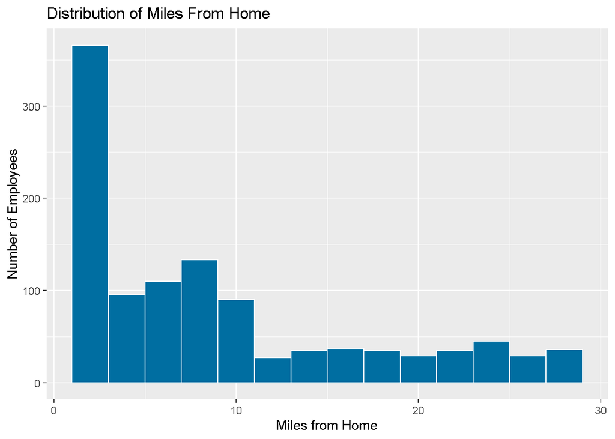

```r
ggplot(data = employee_training, mapping = aes(x = miles_from_home)) +
  geom_histogram(fill = '#006EA1', color = 'white', bins = 15) +
  labs(title = 'Distribution of Miles From Home',
       x = 'Miles from Home',
       y = 'Number of Employees')
```

Now let’s transfrom this variable with the Yeo-Johnson transformation and look at the resulting values.

```r
employee_recipe %>%
  step_YeoJohnson(miles_from_home) %>%
  prep() %>%
  bake(new_data = employee_training)
```

| employee_id | left_company | department | job_level | weekly_hours | business_travel | yrs_at_company | yrs_since_promotion | previous_companies | job_satisfaction | performance_rating | marital_status | miles_from_home | salary |
| --- | --- | --- | --- | --- | --- | --- | --- | --- | --- | --- | --- | --- | --- |
| 3 | Yes | Product Development | Associate | 56 | Rarely | 0 | 0 | 6 | High | Minimally Effective | Single | 1.1251474 | 46235.79 |
| 5 | No | Sales | Associate | 46 | Rarely | 2 | 2 | 2 | Medium | Exceeds Expectations | Married | 1.1251474 | 36634.73 |
| 12 | No | Research | Manager | 48 | Rarely | 9 | 0 | 3 | High | Exceptional | Single | 2.9457845 | 69565.51 |
| 15 | Yes | Marketing | Manager | 57 | Rarely | 4 | 0 | 2 | High | Minimally Effective | Single | 3.4538563 | 63876.58 |
| 17 | No | Research | Associate | 44 | Rarely | 6 | 0 | 3 | Medium | Meets Expectations | Divorced | 1.8630578 | 41883.73 |
| 20 | No | IT and Analytics | Manager | 48 | Rarely | 3 | 1 | 3 | Very High | Meets Expectations | Single | 1.1251474 | 67105.33 |
| 24 | No | Marketing | Manager | 47 | Rarely | 0 | 0 | 2 | Very High | Meets Expectations | Single | 2.9457845 | 69888.14 |
| 26 | No | Marketing | Manager | 51 | Rarely | 14 | 4 | 1 | High | Meets Expectations | Divorced | 1.8630578 | 62391.23 |
| 30 | No | Marketing | Associate | 51 | Rarely | 2 | 2 | 2 | Low | Exceeds Expectations | Single | 1.1251474 | 37230.25 |
| 37 | Yes | Sales | Associate | 57 | Rarely | 3 | 0 | 6 | High | Minimally Effective | Married | 1.4287232 | 38538.66 |

[output cut: 1092 more lines]

Let’s plot the distribution of the results. In the code below, I pipe the results from above into `ggplot`. Although the results are not perfectly symmetric, they are much better than the original distribution of values. In general, I recommend performing this step on all numeric predictors.

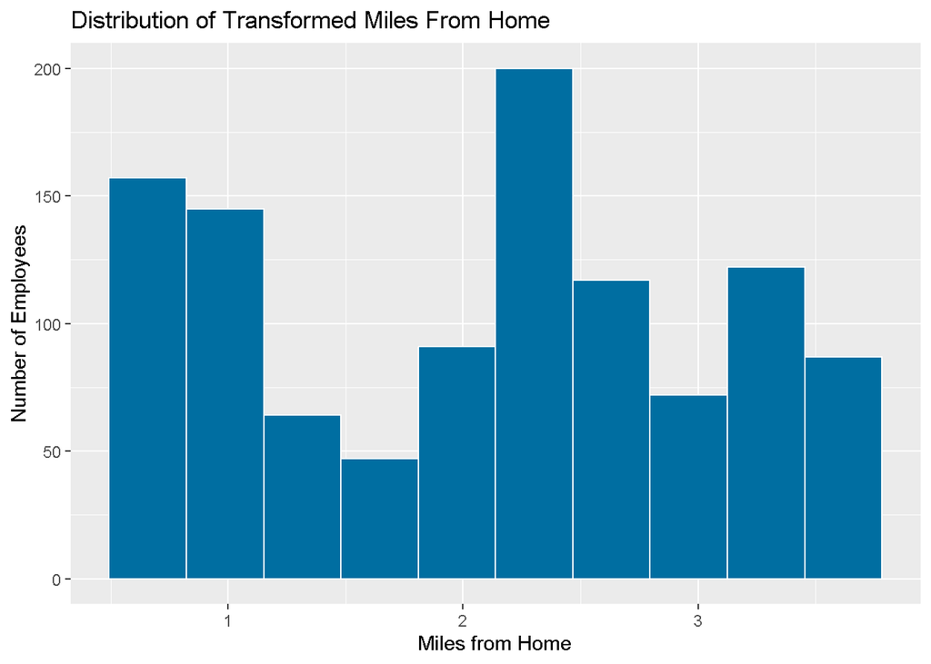

```r
employee_recipe %>%
  step_YeoJohnson(miles_from_home) %>%
  prep() %>%
  bake(new_data = employee_training) %>%

  ggplot(mapping = aes(x = miles_from_home)) +
  geom_histogram(fill = '#006EA1', color = 'white', bins = 10) +
  labs(title = 'Distribution of Transformed Miles From Home',
       x = 'Miles from Home',
       y = 'Number of Employees')
```

### Removing Highly Correlated Predictors

Another common feature engineering task is to remove highly correlated predictor variables. High correlation among numeric predictors is known as multicollinearity and can cause trouble in the model fitting process.

To remove correlated numeric predictors, use `step_corr()`. The `step_corr()` function has a `threshold` argument that will remove correlations at that level. The default threshold is set to 0.9. This corresponds to correlations at 0.9 or greater and -0.9 or less.

Let’s use the `step_corr()` function in on our `employee_recipe`.

```r
# Default threshold of 0.9
employee_recipe %>%
  step_corr(all_numeric(), -all_outcomes(), -has_role('id variable')) %>%
  prep() %>%
  bake(new_data = employee_test)
```

| employee_id | left_company | department | job_level | weekly_hours | business_travel | yrs_at_company | yrs_since_promotion | previous_companies | job_satisfaction | performance_rating | marital_status | miles_from_home | salary |
| --- | --- | --- | --- | --- | --- | --- | --- | --- | --- | --- | --- | --- | --- |
| 7 | No | Marketing | Senior Manager | 44 | Rarely | 1 | 0 | 3 | Low | Meets Expectations | Married | 3 | 88555.65 |
| 11 | No | Sales | Director | 46 | Rarely | 5 | 0 | 1 | Medium | Exceeds Expectations | Married | 16 | 122820.53 |
| 13 | No | Sales | Associate | 48 | Rarely | 5 | 4 | 2 | High | Meets Expectations | Divorced | 26 | 41985.50 |
| 14 | No | Sales | Director | 48 | Rarely | 2 | 1 | 2 | Very High | Meets Expectations | Divorced | 19 | 117368.60 |
| 22 | Yes | Finance and Operations | Manager | 58 | Rarely | 5 | 0 | 3 | Low | Minimally Effective | Single | 9 | 56461.39 |
| 25 | Yes | Marketing | Director | 54 | Rarely | 4 | 1 | 3 | Low | Meets Expectations | Single | 6 | 108649.20 |
| 27 | Yes | Research | Director | 62 | Frequently | 10 | 6 | 6 | Low | Meets Expectations | Single | 16 | 119443.17 |
| 31 | No | Marketing | Manager | 49 | Rarely | 1 | 0 | 1 | Very High | Meets Expectations | Single | 2 | 73141.97 |
| 46 | Yes | Research | Manager | 62 | Rarely | 22 | 15 | 4 | High | Not Effective | Married | 12 | 58286.27 |
| 47 | No | IT and Analytics | Manager | 51 | None | 9 | 8 | 1 | High | Meets Expectations | Single | 23 | 55826.66 |

[output cut: 358 more lines]

```r
lm_model <- linear_reg() %>%
            set_engine('lm') %>%
            set_mode('regression')
```

```r
employee_recipe %>%
  step_corr(all_numeric(), -all_outcomes(), -has_role('id variable'), threshold = 0.2) %>%
  prep() %>%
  bake(new_data = employee_test)
```

| employee_id | left_company | department | job_level | business_travel | yrs_since_promotion | previous_companies | job_satisfaction | performance_rating | marital_status | miles_from_home | salary |
| --- | --- | --- | --- | --- | --- | --- | --- | --- | --- | --- | --- |
| 7 | No | Marketing | Senior Manager | Rarely | 0 | 3 | Low | Meets Expectations | Married | 3 | 88555.65 |
| 11 | No | Sales | Director | Rarely | 0 | 1 | Medium | Exceeds Expectations | Married | 16 | 122820.53 |
| 13 | No | Sales | Associate | Rarely | 4 | 2 | High | Meets Expectations | Divorced | 26 | 41985.50 |
| 14 | No | Sales | Director | Rarely | 1 | 2 | Very High | Meets Expectations | Divorced | 19 | 117368.60 |
| 22 | Yes | Finance and Operations | Manager | Rarely | 0 | 3 | Low | Minimally Effective | Single | 9 | 56461.39 |
| 25 | Yes | Marketing | Director | Rarely | 1 | 3 | Low | Meets Expectations | Single | 6 | 108649.20 |
| 27 | Yes | Research | Director | Frequently | 6 | 6 | Low | Meets Expectations | Single | 16 | 119443.17 |
| 31 | No | Marketing | Manager | Rarely | 0 | 1 | Very High | Meets Expectations | Single | 2 | 73141.97 |
| 46 | Yes | Research | Manager | Rarely | 15 | 4 | High | Not Effective | Married | 12 | 58286.27 |
| 47 | No | IT and Analytics | Manager | None | 8 | 1 | High | Meets Expectations | Single | 23 | 55826.66 |

[output cut: 358 more lines]

### Putting It All Together

To demonstrate how a full recipe is specified, let’s create a recipe object called `employee_numeric` that will train the following steps on our `employee_training` data:

- remove skewness from all numeric predictors
- center and scale all numeric predictors
- remove highly correlated predictors

```r
employee_numeric <- recipe(salary ~ .,
                           data = employee_training) %>%
                    update_role(employee_id, new_role = "id variable") %>%
                    step_YeoJohnson(all_numeric(), -all_outcomes(), -has_role('id variable')) %>%
                    step_normalize(all_numeric(), -all_outcomes(), -has_role('id variable')) %>%
                    step_corr(all_numeric(), -all_outcomes(), -has_role('id variable')) %>%
                    prep()
```

Now that we have our trained recipe, we can apply the transformations to our training and test data with `bake()`.

```r
processed_employee_training <- employee_numeric %>%
                               bake(new_data = employee_training)

processed_employee_test <- employee_numeric %>%
                           bake(new_data = employee_test)
```

```r
# View results
processed_employee_training
```

| employee_id | left_company | department | job_level | weekly_hours | business_travel | yrs_at_company | yrs_since_promotion | previous_companies | job_satisfaction | performance_rating | marital_status | miles_from_home | salary |
| --- | --- | --- | --- | --- | --- | --- | --- | --- | --- | --- | --- | --- | --- |
| 3 | Yes | Product Development | Associate | 1.25687048 | Rarely | -2.19774819 | -1.0775889 | 1.5380272 | High | Minimally Effective | Single | -1.04878859 | 46235.79 |
| 5 | No | Sales | Associate | -0.84186556 | Rarely | -0.95452097 | 0.6275261 | -0.7601978 | Medium | Exceeds Expectations | Married | -1.04878859 | 36634.73 |
| 12 | No | Research | Manager | -0.29497172 | Rarely | 0.63278425 | -1.0775889 | 0.0384511 | High | Exceptional | Single | 0.90943742 | 69565.51 |
| 15 | Yes | Marketing | Manager | 1.39913289 | Rarely | -0.31184455 | -1.0775889 | -0.7601978 | High | Minimally Effective | Single | 1.45590511 | 63876.58 |
| 17 | No | Research | Associate | -1.47973083 | Rarely | 0.13587324 | -1.0775889 | 0.0384511 | Medium | Meets Expectations | Divorced | -0.25511296 | 41883.73 |
| 20 | No | IT and Analytics | Manager | -0.29497172 | Rarely | -0.59794297 | 0.1181138 | 0.0384511 | Very High | Meets Expectations | Single | -1.04878859 | 67105.33 |
| 24 | No | Marketing | Manager | -0.55813030 | Rarely | -2.19774819 | -1.0775889 | -0.7601978 | Very High | Meets Expectations | Single | 0.90943742 | 69888.14 |
| 26 | No | Marketing | Manager | 0.38873457 | Rarely | 1.22694388 | 1.1225945 | -1.9189752 | High | Meets Expectations | Divorced | -0.25511296 | 62391.23 |
| 30 | No | Marketing | Associate | 0.38873457 | Rarely | -0.95452097 | 0.6275261 | -0.7601978 | Low | Exceeds Expectations | Single | -1.04878859 | 37230.25 |
| 37 | Yes | Sales | Associate | 1.39913289 | Rarely | -0.59794297 | -1.0775889 | 1.5380272 | High | Minimally Effective | Married | -0.72227099 | 38538.66 |

[output cut: 1092 more lines]

```r
# View results
processed_employee_test
```

| employee_id | left_company | department | job_level | weekly_hours | business_travel | yrs_at_company | yrs_since_promotion | previous_companies | job_satisfaction | performance_rating | marital_status | miles_from_home | salary |
| --- | --- | --- | --- | --- | --- | --- | --- | --- | --- | --- | --- | --- | --- |
| 7 | No | Marketing | Senior Manager | -1.47973083 | Rarely | -1.43455800 | -1.0775889 | 0.0384511 | Low | Meets Expectations | Married | -0.72227099 | 88555.65 |
| 11 | No | Sales | Director | -0.84186556 | Rarely | -0.07172264 | -1.0775889 | -1.9189752 | Medium | Exceeds Expectations | Married | 0.98305276 | 122820.53 |
| 13 | No | Sales | Associate | -0.29497172 | Rarely | -0.07172264 | 1.1225945 | -0.7601978 | High | Meets Expectations | Divorced | 1.55121362 | 41985.50 |
| 14 | No | Sales | Director | -0.29497172 | Rarely | -0.95452097 | 0.1181138 | -0.7601978 | Very High | Meets Expectations | Divorced | 1.18135198 | 117368.60 |
| 22 | Yes | Finance and Operations | Manager | 1.53280269 | Rarely | -0.07172264 | -1.0775889 | 0.0384511 | Low | Minimally Effective | Single | 0.34522663 | 56461.39 |
| 25 | Yes | Marketing | Director | 0.94362161 | Rarely | -0.31184455 | 0.1181138 | 0.0384511 | Low | Meets Expectations | Single | -0.07534599 | 108649.20 |
| 27 | Yes | Research | Director | 1.99373930 | Frequently | 0.76959316 | 1.3782866 | 1.5380272 | Low | Meets Expectations | Single | 0.98305276 | 119443.17 |
| 31 | No | Marketing | Manager | -0.05052215 | Rarely | -1.43455800 | -1.0775889 | -1.9189752 | Very High | Meets Expectations | Single | -1.04878859 | 73141.97 |
| 46 | Yes | Research | Manager | 1.99373930 | Rarely | 1.88886011 | 1.8328892 | 0.6448279 | High | Not Effective | Married | 0.65876337 | 58286.27 |
| 47 | No | IT and Analytics | Manager | 0.38873457 | None | 0.63278425 | 1.5397294 | -1.9189752 | High | Meets Expectations | Single | 1.40547987 | 55826.66 |

[output cut: 358 more lines]

## Processing Categorical Variables

For machine learning applications, all data in a feature matrix must be numeric. Therefore, any character or factor variables in a data frame must be transformed into numbers.

How is this done? The two primary methods are dummy variable creation and one-hot encoding. Both methods are performed by the `step_dummy()` function.

Let’s see an example of both methods using our `employee_recipe` object. We will transform the `job_level` variable using one-hot encoding and dummy variables.

### One-Hot Encoding

The `job_level` variable in `employee_training` has 5 unique values: Associate, Manager, Senior Manager, Director, and Vice President.

One-hot encoding will produce 5 new variables that are either 0 or 1 depending on whether the value was present in the `job_level` row.

The new variables are created with the following naming convention: `variable_name_level`

For example, `job_level_Associate` will be one variable that is created. If the value of `job_level` for any row in the data is “Associate”, then this new variable will be equal to 1 and 0 otherwise.

Let’s see how we can do this with `step_dummy()`

```r
# One-hot encode job_level
employee_recipe %>%
  step_dummy(job_level, one_hot = TRUE) %>%
  prep() %>%
  bake(new_data = employee_training)
```

| employee_id | left_company | department | weekly_hours | business_travel | yrs_at_company | yrs_since_promotion | previous_companies | job_satisfaction | performance_rating | marital_status | miles_from_home | salary | job_level_Associate | job_level_Manager | job_level_Senior.Manager | job_level_Director | job_level_Vice.President |
| --- | --- | --- | --- | --- | --- | --- | --- | --- | --- | --- | --- | --- | --- | --- | --- | --- | --- |
| 3 | Yes | Product Development | 56 | Rarely | 0 | 0 | 6 | High | Minimally Effective | Single | 2 | 46235.79 | 1 | 0 | 0 | 0 | 0 |
| 5 | No | Sales | 46 | Rarely | 2 | 2 | 2 | Medium | Exceeds Expectations | Married | 2 | 36634.73 | 1 | 0 | 0 | 0 | 0 |
| 12 | No | Research | 48 | Rarely | 9 | 0 | 3 | High | Exceptional | Single | 15 | 69565.51 | 0 | 1 | 0 | 0 | 0 |
| 15 | Yes | Marketing | 57 | Rarely | 4 | 0 | 2 | High | Minimally Effective | Single | 24 | 63876.58 | 0 | 1 | 0 | 0 | 0 |
| 17 | No | Research | 44 | Rarely | 6 | 0 | 3 | Medium | Meets Expectations | Divorced | 5 | 41883.73 | 1 | 0 | 0 | 0 | 0 |
| 20 | No | IT and Analytics | 48 | Rarely | 3 | 1 | 3 | Very High | Meets Expectations | Single | 2 | 67105.33 | 0 | 1 | 0 | 0 | 0 |
| 24 | No | Marketing | 47 | Rarely | 0 | 0 | 2 | Very High | Meets Expectations | Single | 15 | 69888.14 | 0 | 1 | 0 | 0 | 0 |
| 26 | No | Marketing | 51 | Rarely | 14 | 4 | 1 | High | Meets Expectations | Divorced | 5 | 62391.23 | 0 | 1 | 0 | 0 | 0 |
| 30 | No | Marketing | 51 | Rarely | 2 | 2 | 2 | Low | Exceeds Expectations | Single | 2 | 37230.25 | 1 | 0 | 0 | 0 | 0 |
| 37 | Yes | Sales | 57 | Rarely | 3 | 0 | 6 | High | Minimally Effective | Married | 3 | 38538.66 | 1 | 0 | 0 | 0 | 0 |

[output cut: 1092 more lines]

### Dummy Variables

Creating dummy variables is similar to one-hot encoding, except that one level is always left out. Therefore, if we create dummy variables from the `job_level()` function, we will have 4 new variables instead of 5.

This method is generally preferred to one-hot encoding because many statistical models will fail with one-hot encoding. This is because it creates multicollinearity in the one-hot encoded variables.

In fact, the default of `step_dummy()` is to have `one_hot set to FALSE. This is what I recommend for most machine learning applications.

Let’s see the difference when we use the default settings of `step_dummy()`. Notice that `job_level_Associate` is now excluded.

```r
employee_recipe %>%
  step_dummy(job_level) %>%
  prep() %>%
  bake(new_data = employee_training)
```

| employee_id | left_company | department | weekly_hours | business_travel | yrs_at_company | yrs_since_promotion | previous_companies | job_satisfaction | performance_rating | marital_status | miles_from_home | salary | job_level_Manager | job_level_Senior.Manager | job_level_Director | job_level_Vice.President |
| --- | --- | --- | --- | --- | --- | --- | --- | --- | --- | --- | --- | --- | --- | --- | --- | --- |
| 3 | Yes | Product Development | 56 | Rarely | 0 | 0 | 6 | High | Minimally Effective | Single | 2 | 46235.79 | 0 | 0 | 0 | 0 |
| 5 | No | Sales | 46 | Rarely | 2 | 2 | 2 | Medium | Exceeds Expectations | Married | 2 | 36634.73 | 0 | 0 | 0 | 0 |
| 12 | No | Research | 48 | Rarely | 9 | 0 | 3 | High | Exceptional | Single | 15 | 69565.51 | 1 | 0 | 0 | 0 |
| 15 | Yes | Marketing | 57 | Rarely | 4 | 0 | 2 | High | Minimally Effective | Single | 24 | 63876.58 | 1 | 0 | 0 | 0 |
| 17 | No | Research | 44 | Rarely | 6 | 0 | 3 | Medium | Meets Expectations | Divorced | 5 | 41883.73 | 0 | 0 | 0 | 0 |
| 20 | No | IT and Analytics | 48 | Rarely | 3 | 1 | 3 | Very High | Meets Expectations | Single | 2 | 67105.33 | 1 | 0 | 0 | 0 |
| 24 | No | Marketing | 47 | Rarely | 0 | 0 | 2 | Very High | Meets Expectations | Single | 15 | 69888.14 | 1 | 0 | 0 | 0 |
| 26 | No | Marketing | 51 | Rarely | 14 | 4 | 1 | High | Meets Expectations | Divorced | 5 | 62391.23 | 1 | 0 | 0 | 0 |
| 30 | No | Marketing | 51 | Rarely | 2 | 2 | 2 | Low | Exceeds Expectations | Single | 2 | 37230.25 | 0 | 0 | 0 | 0 |
| 37 | Yes | Sales | 57 | Rarely | 3 | 0 | 6 | High | Minimally Effective | Married | 3 | 38538.66 | 0 | 0 | 0 | 0 |

[output cut: 1092 more lines]

## Creating a Feature Engineering Pipeline

When creating feature engineering recipes with many steps, we have to keep in mind that the transformations are carried out in the order that we enter them. So if we use `step_dummy()` before `step_normalize()` our dummy variables will be normalized because they are numeric at the point when `step_normalize()` is called.

To make sure we don’t get any unexpected results, it’s best to use the following ordering of high-level transformations:

1. Skewness Transformations - `step_YeoJohnson()`
2. Centering, Scaling, or Normalization on Numeric Predictors
3. Dummy Variables for Categorical Data

Let’s put together all that we have learned to create the following feature engineering pipeline on the `employee_training` data:

- Correct for skewness on all numeric predictors
- Normalize all numeric predictors
- Create dummy variables for all character or factor predictors (we can use the all_nominal() selector for this)

```r
employee_transformations <- recipe(salary ~ .,
                                   data = employee_training) %>%
                            update_role(employee_id, new_role = 'id variable') %>%
                            # Transformation steps
                            step_YeoJohnson(all_numeric(), -all_outcomes(), -has_role('id variable')) %>%
                            step_normalize(all_numeric(), -all_outcomes(), -has_role('id variable')) %>%
                            step_dummy(all_nominal(), -all_outcomes()) %>%
                            # Train transformations on employee_training
                            prep()

# Apply to employee_test
employee_transformations %>%
  bake(new_data = employee_test)
```

| employee_id | weekly_hours | yrs_at_company | yrs_since_promotion | previous_companies | miles_from_home | salary | left_company_Yes | department_Sales | department_Research | department_Product.Development | department_IT.and.Analytics | department_Finance.and.Operations | job_level_Manager | job_level_Senior.Manager | job_level_Director | job_level_Vice.President | business_travel_Rarely | business_travel_Frequently | job_satisfaction_Medium | job_satisfaction_High | job_satisfaction_Very.High | performance_rating_Minimally.Effective | performance_rating_Meets.Expectations | performance_rating_Exceeds.Expectations | performance_rating_Exceptional | marital_status_Married | marital_status_Divorced |
| --- | --- | --- | --- | --- | --- | --- | --- | --- | --- | --- | --- | --- | --- | --- | --- | --- | --- | --- | --- | --- | --- | --- | --- | --- | --- | --- | --- |
| 7 | -1.47973083 | -1.43455800 | -1.0775889 | 0.0384511 | -0.72227099 | 88555.65 | 0 | 0 | 0 | 0 | 0 | 0 | 0 | 1 | 0 | 0 | 1 | 0 | 0 | 0 | 0 | 0 | 1 | 0 | 0 | 1 | 0 |
| 11 | -0.84186556 | -0.07172264 | -1.0775889 | -1.9189752 | 0.98305276 | 122820.53 | 0 | 1 | 0 | 0 | 0 | 0 | 0 | 0 | 1 | 0 | 1 | 0 | 1 | 0 | 0 | 0 | 0 | 1 | 0 | 1 | 0 |
| 13 | -0.29497172 | -0.07172264 | 1.1225945 | -0.7601978 | 1.55121362 | 41985.50 | 0 | 1 | 0 | 0 | 0 | 0 | 0 | 0 | 0 | 0 | 1 | 0 | 0 | 1 | 0 | 0 | 1 | 0 | 0 | 0 | 1 |
| 14 | -0.29497172 | -0.95452097 | 0.1181138 | -0.7601978 | 1.18135198 | 117368.60 | 0 | 1 | 0 | 0 | 0 | 0 | 0 | 0 | 1 | 0 | 1 | 0 | 0 | 0 | 1 | 0 | 1 | 0 | 0 | 0 | 1 |
| 22 | 1.53280269 | -0.07172264 | -1.0775889 | 0.0384511 | 0.34522663 | 56461.39 | 1 | 0 | 0 | 0 | 0 | 1 | 1 | 0 | 0 | 0 | 1 | 0 | 0 | 0 | 0 | 1 | 0 | 0 | 0 | 0 | 0 |
| 25 | 0.94362161 | -0.31184455 | 0.1181138 | 0.0384511 | -0.07534599 | 108649.20 | 1 | 0 | 0 | 0 | 0 | 0 | 0 | 0 | 1 | 0 | 1 | 0 | 0 | 0 | 0 | 0 | 1 | 0 | 0 | 0 | 0 |
| 27 | 1.99373930 | 0.76959316 | 1.3782866 | 1.5380272 | 0.98305276 | 119443.17 | 1 | 0 | 1 | 0 | 0 | 0 | 0 | 0 | 1 | 0 | 0 | 1 | 0 | 0 | 0 | 0 | 1 | 0 | 0 | 0 | 0 |
| 31 | -0.05052215 | -1.43455800 | -1.0775889 | -1.9189752 | -1.04878859 | 73141.97 | 0 | 0 | 0 | 0 | 0 | 0 | 1 | 0 | 0 | 0 | 1 | 0 | 0 | 0 | 1 | 0 | 1 | 0 | 0 | 0 | 0 |
| 46 | 1.99373930 | 1.88886011 | 1.8328892 | 0.6448279 | 0.65876337 | 58286.27 | 1 | 0 | 1 | 0 | 0 | 0 | 1 | 0 | 0 | 0 | 1 | 0 | 0 | 1 | 0 | 0 | 0 | 0 | 0 | 1 | 0 |
| 47 | 0.38873457 | 0.63278425 | 1.5397294 | -1.9189752 | 1.40547987 | 55826.66 | 0 | 0 | 0 | 0 | 1 | 0 | 1 | 0 | 0 | 0 | 0 | 0 | 0 | 1 | 0 | 0 | 1 | 0 | 0 | 0 | 0 |

[output cut: 358 more lines]

## Step 4. Create a Workflow

The `workflow` package was designed to combine models and recipes into a single object. To create a workflow, we start with `workflow()` to create an empty workflow and then add out model and recipe with `add_model()` and `add_recipe()`.

```r
projects_workflow <- workflow() %>%
                        add_model(lm_model) %>%
                        add_recipe(employee_transformations)
projects_workflow
```

```
## ══ Workflow ════════════════════════════════════════════════════════════════════
## Preprocessor: Recipe
## Model: linear_reg()
##
## ── Preprocessor ────────────────────────────────────────────────────────────────
## 3 Recipe Steps
##
## • step_YeoJohnson()
## • step_normalize()
## • step_dummy()
##
## ── Model ───────────────────────────────────────────────────────────────────────
## Linear Regression Model Specification (regression)
##
## Computational engine: lm
```

## Step 5. Execute the Workflow

The `last_fit()` function will take a workflow object and apply the recipe and model to a specified data split object.

The `last_fit()` function will then train the feature engineering steps on the training data, fit the model to the training data, apply the feature engineering steps to the test data, and calculate the predictions on the test data, **all in one step**!

```r
projects_fit <- projects_workflow %>%
                   last_fit(split = employee_split)
```

To obtain the performance metrics and predictions on the test set, we use the `collect_metrics()` and `collect_predictions()` functions on our `projects_fit` object.

```r
# Obtain performance metrics on test data
projects_fit %>% collect_metrics()
```

| .metric | .estimator | .estimate | .config |
| --- | --- | --- | --- |
| rmse | standard | 7177.5893995 | Preprocessor1_Model1 |
| rsq | standard | 0.9644144 | Preprocessor1_Model1 |

We can save the test set predictions by using the `collect_predictions()` function. This function returns a data frame which will have the response variables values from the test set and a column named `.pred` with the model predictions.

```r
# Obtain test set predictions data frame
projects_results <- projects_fit %>%
                collect_predictions()
# View results
projects_results
```

| id | .pred | .row | salary | .config |
| --- | --- | --- | --- | --- |
| train/test split | 89687.76 | 7 | 88555.65 | Preprocessor1_Model1 |
| train/test split | 119085.19 | 11 | 122820.53 | Preprocessor1_Model1 |
| train/test split | 40593.21 | 13 | 41985.50 | Preprocessor1_Model1 |
| train/test split | 119628.91 | 14 | 117368.60 | Preprocessor1_Model1 |
| train/test split | 71381.50 | 22 | 56461.39 | Preprocessor1_Model1 |
| train/test split | 121568.54 | 25 | 108649.20 | Preprocessor1_Model1 |
| train/test split | 121024.23 | 27 | 119443.17 | Preprocessor1_Model1 |
| train/test split | 70063.53 | 31 | 73141.97 | Preprocessor1_Model1 |
| train/test split | 71977.26 | 46 | 58286.27 | Preprocessor1_Model1 |
| train/test split | 69366.66 | 47 | 55826.66 | Preprocessor1_Model1 |

[output cut: 358 more lines]

### R2 Plot

Finally, lets use the `projects_results` data frame to make an R2 plot to visualize our model performance on the test data set.

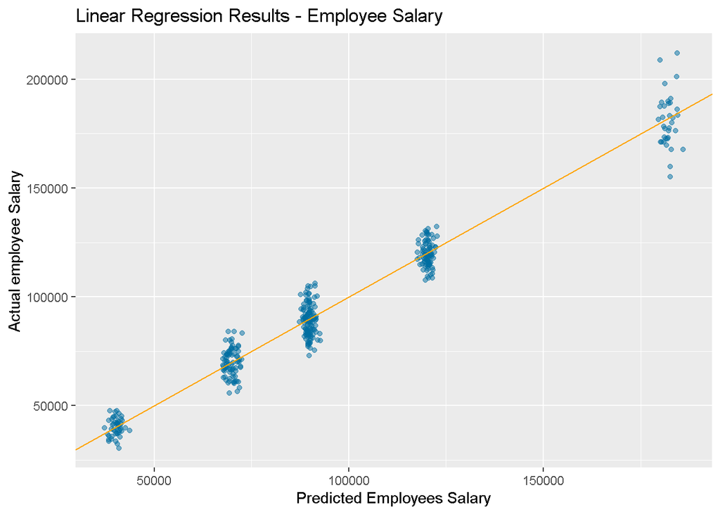

```r
ggplot(data = projects_results,
       mapping = aes(x = .pred, y = salary)) +
  geom_point(color = '#006EA1', alpha = 0.5) +
  geom_abline(intercept = 1, slope = 1, color = 'orange') +
  labs(title = 'Linear Regression Results - Employee Salary',
       x = 'Predicted Employees Salary',
       y = 'Actual employee Salary')
```

- Received from https://github.com/dsvancer/gbus-738-r-tutorials